# Data Scientist Nanodegree Program

This is a capstone project of data scientist nanodegree program offered by Udacity.

## Blog post link

This is the link of my blog post for this project.https://medium.com/@sidharth.ku178/dog-breed-classification-with-cnn-16faeabd6255

All the instructions are provided in each and every section.

> **Note:** By using the **Shift + Enter** keyboard shortcut the markdown cell and code will be executed. By double-clicking the cell the markdown cells can also be edited.

### Overview

Here i made the first step to develope an algorithm and made a web application. After finish of the project, our code will take an image as input. It will identify the breed of the dog if the input image is a dog's image.If we will give a image of human as input then it will identify that it is a human.

[figure not shown]

### The Road Ahead

There are some steps that how we create this model.

- Step 1: Import the Datasets
- Step 2: Detect the Humans
- Step 3: Detect Dogs
- Step 4: Create a CNN to Classify the Dog Breeds (from Scratch)
- Step 5: Use a CNN to Classify the Dog Breeds (using Transfer Learning)
- Step 6: Create a CNN to the Classify Dog Breeds (using Transfer Learning)
- Step 7: Write your Algorithm
- Step 8: Test Your Algorithm

## Step 1: Import the Datasets

### Import the dataset of dog

here we import the dataset containing different image of dogs . These are the functions from the scikit-learn library:

- `train_files`, `valid_files`, `test_files` - This numpy arrays contain the file paths to images
- `train_targets`, `valid_targets`, `test_targets` -This numpy arrays also contain onehot-encoded classification labels
- `dog_names` - For translating labels, this is a list of name of string valued dog breed

```python
#import all the libraries here
from sklearn.datasets import load_files
from keras.utils import np_utils
import numpy as np
from glob import glob

# For the loading of validation, test and train datasets we define the function here
def load_dataset(path):
    data = load_files(path)
    dog_files = np.array(data['filenames'])
    dog_targets = np_utils.to_categorical(np.array(data['target']), 133)
    return dog_files, dog_targets

# Here we load validation, train and test datasets
train_files, train_targets = load_dataset('../../../data/dog_images/train')
valid_files, valid_targets = load_dataset('../../../data/dog_images/valid')
test_files, test_targets = load_dataset('../../../data/dog_images/test')

# Here load the dog name list
dog_names = [item[20:-1] for item in sorted(glob("../../../data/dog_images/train/*/"))]

# print the dataset statistics
print('There are %d total dog categories.' % len(dog_names))
print('There are %s total dog images.\n' % len(np.hstack([train_files, valid_files, test_files])))
print('There are %d training dog images.' % len(train_files))
print('There are %d validation dog images.' % len(valid_files))
print('There are %d test dog images.'% len(test_files))
```

```
There are 133 total dog categories.
There are 8351 total dog images.

There are 6680 training dog images.
There are 835 validation dog images.
There are 836 test dog images.
```

### Import The Human Dataset Here

Here we import human image dataset from where we can stored file paths in the numpy array `human_files`.

```python
import random
random.seed(8675309)

# In shuffled human dataset load the filenames here
human_files = np.array(glob("../../../data/lfw/*/*"))
random.shuffle(human_files)

# print the dataset statistics here
print('There are %d total human images.' % len(human_files))
```

```
There are 13233 total human images.
```

## Step 2: Detect The Humans

Here implementation of [Haar feature-based cascade classifiers] of OpenCV is used (http://docs.opencv.org/trunk/d7/d8b/tutorial_py_face_detection.html) for detecting the image of human faces. Many pre trained face detectors are stored in xml file here which is provided by OpenCV. [github](https://github.com/opencv/opencv/tree/master/data/haarcascades). Here we have stored one of the detector in the `haarcascades` directory .

```
Number of faces detected: 1
```

```python
import cv2
import matplotlib.pyplot as plt
%matplotlib inline

# Here we will extract the pretrained face detector
face_cascade = cv2.CascadeClassifier('haarcascades/haarcascade_frontalface_alt.xml')

# Here color image loded
img = cv2.imread(human_files[3])
# Here we convert colour image to the grayscale
gray = cv2.cvtColor(img, cv2.COLOR_BGR2GRAY)

# Now we will detect the faces in the image
faces = face_cascade.detectMultiScale(gray)

# Now we will print how many faces identified in the image
print('Number of faces detected:', len(faces))

# Here we will set the bounding box for identified faces
for (x,y,w,h) in faces:
    # Now we will add bounding box
    cv2.rectangle(img,(x,y),(x+w,y+h),(255,0,0),2)

# Here for plotting, we will change the BGR image to RGB
cv_rgb = cv2.cvtColor(img, cv2.COLOR_BGR2RGB)

# Here we will show the detected image with the bounding box
plt.imshow(cv_rgb)
plt.show()
```

[output not shown]

To convert images to the grayscale this is the standard procedure before use of face dector. The `detectMultiScale` function takes grayscale img as a parameter and it also execute classifier which is stored in `face_cascade` .

The code in previous cell has a numpy array that is `faces` which store detected faces and all identified face is also an one dimenddional array having four entries which shows the detected face bonding box.The vertical and horrizontal of bounding box is detected by the first teo entries of the array where the height and weight of bounding box is specified by the two entries.

### Write The Human Face Detector

When there is a human face image the function will return `True` and if there is not a human face in the image it returns `False` . Now we will write this function .

```python
# if there is a human face image the function will return true otherwise it returns false
def face_detector(img_path):
    img = cv2.imread(img_path)
    gray = cv2.cvtColor(img, cv2.COLOR_BGR2GRAY)
    faces = face_cascade.detectMultiScale(gray)
    return len(faces) > 0
```

### (IMPLEMENTATION) Assess the Human Face Detector

**Question 1:** To test the performance of the `face_detector` function use this code cell given below .

- What is the percentage of the first 100 images having a detected human face in `human_files` ?
- What is the percentage of first 100 images in having a detected human face `dog_files` ?

```python
from tqdm import tqdm

human_files_short = human_files[:100]


#-#-# Do NOT modify the code above this line. #-#-#

## TODO: Test the performance of the face_detector algorithm
## on the images in human_files_short and dog_files_short.

def face_detection_test(files):
    detection_cnt = 0;
    total_cnt = len(files)
    for file in files:
        detection_cnt += face_detector(file)
    return detection_cnt, total_cnt
```

**Question 2:** This algorithmic choice necessitates that we communicate to the user that we accept human images only when they provide a clear view of a face (otherwise, we risk having unneccessarily frustrated users!). In your opinion, is this a reasonable expectation to pose on the user? If not, can you think of a way to detect humans in images that does not necessitate an image with a clearly presented face?

**Answer:**

For detecting human images we prefer the face detector from opencv in this algorithm and you can also use other approches.For test and design use this face detection algorithm.

```python
## On LFW dataset this is a face detection algorithm

print("detect face in human_files: {} / {}".format(face_detection_test(human_files_short)[0], face_detection_test(human_files_short)[1]))
```

```
detect face in human_files: 100 / 100
```

## Step 3: Detect Dogs

Now we will use a pretrained model in this section for detecting the images of dogs [ResNet-50](http://ethereon.github.io/netscope/#/gist/db945b393d40bfa26006) . Along the weights which is trained on [ImageNet](http://www.image-net.org/) is very popular and large dataset which is used for classification of images.Over 10 million urls with linking to image having an object from one of these [1000 categories](https://gist.github.com/yrevar/942d3a0ac09ec9e5eb3a) is present in ImageNet. When we will give an input this predefined ResNet-50 model returns an object prediction.

```python
from keras.applications.resnet50 import ResNet50

ResNet50_model = ResNet50(weights='imagenet')
```

### Pre-process the Data

A four dimenssional array is required as input to Keras CNNs with shape when use of TensorFlow as backend .

$$ (\text{nb_samples}, \text{rows}, \text{columns}, \text{channels}), $$

Here `nb_samples` represents to the total number of images where `columns` and`rows` and `channels` represents to the number of columns and rows and channels for every image .  
The `path_to_tensor` function returns a four dimenssional tensor suitable pixels by taking a string-valued file path to the color image as input .This function loads the image as input and resize it as a square image . The returned tensor will have shape as we processing a simple sample or image as input.

$$ (1, 224, 224, 3). $$

The `paths_to_tensor` function returns a four dimenssional tensor having shape by taking input that is a numpy array of string-valued image paths .

$$ (\text{nb_samples}, 224, 224, 3). $$

Here, `nb_samples` is the number of images or sample . It's good to think about `nb_samples` as the no. of three dimenssional tensors in the dataset!

```python
from keras.preprocessing import image
from tqdm import tqdm

def path_to_tensor(img_path):
    # Here we will load RGB image as PIL.Image.Image type
    img = image.load_img(img_path, target_size=(224, 224))
    #Now we will convert  to three dimenssiona tensor with shape (224, 224, 3) from PIL.Image.Image type
    x = image.img_to_array(img)
    # Here we will convert  to four dimenssiona tensor from three dimenssiona tensor with shape (1, 224, 224, 3) which return four dimenssional tensor
    return np.expand_dims(x, axis=0)

def paths_to_tensor(img_paths):
    list_of_tensors = [path_to_tensor(img_path) for img_path in tqdm(img_paths)]
    return np.vstack(list_of_tensors)
```

### Making Predictions with ResNet-50

By reordering the channels the RGB image is converted to BGR .Here getting the four dimenssional tensor ready for the ResNet-50 which requires some of additional processing'.From every pixel in all image , the mean pixil should be substracted which is implemented in the function `preprocess_input`.

Now we are ready to use the model for extracting the prediction and we also have a way for formatting images to supply to ResNet-50 which is implemented in the function `ResNet50_predict_labels`

```python
from keras.applications.resnet50 import preprocess_input, decode_predictions

def ResNet50_predict_labels(img_path):
    #  For the image located at the img_path ,it will return prediction vactor.
    img = preprocess_input(path_to_tensor(img_path))
    return np.argmax(ResNet50_model.predict(img))
```

### Write a Dog Detector

We will see the categories that correspond to dictionary keys 151-268 and also correspond to dogs which are appear in an uninterrupted sequence by looking at this [dictionary](https://gist.github.com/yrevar/942d3a0ac09ec9e5eb3a).

To complete the `dog_detector` function we will use these ideas below, that returns `True` and returns `False` if a dog is not detected in the image .

```python
###  if a dog is identified in the image as input stored at img_path it returns  "True"
def dog_detector(img_path):
    prediction = ResNet50_predict_labels(img_path)
    return ((prediction <= 268) & (prediction >= 151))
```

### (IMPLEMENTATION) Assess the Dog Detector

**Question 3:** Use the code cell below to test the performance of your `dog_detector` function.

- What percentage of the images in `human_files_short` have a detected dog?
- What percentage of the images in `dog_files_short` have a detected dog?

```python
### Here we will take performance of the dog_detector function on the images in dog_files_short and human_files_short  .
def dog_detector_test(files):
    detection_cnt = 0;
    total_cnt = len(files)
    for file in files:
        detection_cnt += dog_detector(file)
    return detection_cnt, total_cnt
```

```python
print("detect a dog in dog_files: {} / {}".format(dog_detector_test(dog_files_short)[0], dog_detector_test(dog_files_short)[1]))
```

```
detect a dog in dog_files: 100 / 100
```

## Step 4: Create a CNN to Classify Dog Breeds (from Scratch)

Be careful with adding too many trainable layers! More parameters means longer training, which means you are more likely to need a GPU to accelerate the training process. Thankfully, Keras provides a handy estimate of the time that each epoch is likely to take; you can extrapolate this estimate to figure out how long it will take for your algorithm to train.

We mention that the task of assigning breed to dogs from images is considered exceptionally challenging. To see why, consider that *even a human* would have great difficulty in distinguishing between a Brittany and a Welsh Springer Spaniel.

| Brittany | Welsh Springer Spaniel |
| --- | --- |

It is not difficult to find other dog breed pairs with minimal inter-class variation (for instance, Curly-Coated Retrievers and American Water Spaniels).

| Curly-Coated Retriever | American Water Spaniel |
| --- | --- |

Likewise, recall that labradors come in yellow, chocolate, and black. Your vision-based algorithm will have to conquer this high intra-class variation to determine how to classify all of these different shades as the same breed.

| Yellow Labrador | Chocolate Labrador | Black Labrador |
| --- | --- | --- |

We also mention that random chance presents an exceptionally low bar: setting aside the fact that the classes are slightly imabalanced, a random guess will provide a correct answer roughly 1 in 133 times, which corresponds to an accuracy of less than 1%.

Remember that the practice is far ahead of the theory in deep learning. Experiment with many different architectures, and trust your intuition. And, of course, have fun!

### Pre-process the Data

We rescale the images by dividing every pixel in every image by 255.

```python
from PIL import ImageFile
ImageFile.LOAD_TRUNCATED_IMAGES = True

#  For Keras we will pre-process the data
train_tensors = paths_to_tensor(train_files).astype('float32')/255
valid_tensors = paths_to_tensor(valid_files).astype('float32')/255
test_tensors = paths_to_tensor(test_files).astype('float32')/255
```

### (IMPLEMENTATION) Model Architecture

Create a CNN to classify dog breed. At the end of your code cell block, summarize the layers of your model by executing the line:

```
    model.summary()
```

We have imported some Python modules to get you started, but feel free to import as many modules as you need. If you end up getting stuck, here's a hint that specifies a model that trains relatively fast on CPU and attains >1% test accuracy in 5 epochs:

[figure not shown]

**Question 4:** Outline the steps you took to get to your final CNN architecture and your reasoning at each step. If you chose to use the hinted architecture above, describe why you think that CNN architecture should work well for the image classification task.

```python
from keras.layers import Conv2D, MaxPooling2D, GlobalAveragePooling2D
from keras.layers import Dropout, Flatten, Dense
from keras.models import Sequential


# here we will Ddfine our architecture.
model = Sequential()


model.add(Conv2D(16, (3, 3), activation='relu', input_shape=(224,224,3)))
model.add(MaxPooling2D(pool_size=(2, 2)))
model.add(Conv2D(32, (3, 3), activation='relu'))
model.add(MaxPooling2D(pool_size=(2,2)))

model.add(Conv2D(64, (3, 3), activation='relu'))
model.add(MaxPooling2D(pool_size=(2, 2)))

model.add(GlobalAveragePooling2D())

model.add(Dense(133, activation='relu'))

model.summary()
```

```
_________________________________________________________________
Layer (type)                 Output Shape              Param #
=================================================================
conv2d_1 (Conv2D)            (None, 222, 222, 16)      448
_________________________________________________________________
max_pooling2d_3 (MaxPooling2 (None, 111, 111, 16)      0
_________________________________________________________________
conv2d_2 (Conv2D)            (None, 109, 109, 32)      4640
_________________________________________________________________
max_pooling2d_4 (MaxPooling2 (None, 54, 54, 32)        0
_________________________________________________________________
conv2d_3 (Conv2D)            (None, 52, 52, 64)        18496
_________________________________________________________________
max_pooling2d_5 (MaxPooling2 (None, 26, 26, 64)        0
_________________________________________________________________
global_average_pooling2d_1 ( (None, 64)                0
_________________________________________________________________
dense_1 (Dense)              (None, 133)               8645
=================================================================
Total params: 32,229
Trainable params: 32,229
Non-trainable params: 0
_________________________________________________________________
```

### Compile the Model

```python
model.compile(optimizer='rmsprop', loss='categorical_crossentropy', metrics=['accuracy'])
```

### (IMPLEMENTATION) Train the Model

Train your model in the code cell below. Use model checkpointing to save the model that attains the best validation loss.

You are welcome to [augment the training data](https://blog.keras.io/building-powerful-image-classification-models-using-very-little-data.html), but this is not a requirement.

```python
from keras.callbacks import ModelCheckpoint

### Here we will specify how many epochs that we would like to use for train the model.

epochs = 10


checkpointer = ModelCheckpoint(filepath='saved_models/weights.best.from_scratch.hdf5',
                               verbose=1, save_best_only=True)

model.fit(train_tensors, train_targets,
          validation_data=(valid_tensors, valid_targets),
          epochs=epochs, batch_size=20, callbacks=[checkpointer], verbose=1)
```

```
Train on 6680 samples, validate on 835 samples
```

```
<keras.callbacks.History at 0x7f1d362b48d0>
```

### Load the Model with the Best Validation Loss

```python
model.load_weights('saved_models/weights.best.from_scratch.hdf5')
```

### Test the Model

Try out your model on the test dataset of dog images. Ensure that your test accuracy is greater than 1%.

```python
# For each image in test set ,get the index of predicted dog breed
dog_breed_predictions = [np.argmax(model.predict(np.expand_dims(tensor, axis=0))) for tensor in test_tensors]

# here we will report the test accuracy
test_accuracy = 100*np.sum(np.array(dog_breed_predictions)==np.argmax(test_targets, axis=1))/len(dog_breed_predictions)
print('Test accuracy: %.4f%%' % test_accuracy)
```

```
Test accuracy: 0.9569%
```

## Step 5: Use a CNN to Classify Dog Breeds

To reduce training time without sacrificing accuracy, we show you how to train a CNN using transfer learning. In the following step, you will get a chance to use transfer learning to train your own CNN.

### Obtain Bottleneck Features

```python
bottleneck_features = np.load('bottleneck_features/DogVGG16Data.npz')
train_VGG16 = bottleneck_features['train']
valid_VGG16 = bottleneck_features['valid']
test_VGG16 = bottleneck_features['test']
```

### Model Architecture

The model uses the the pre-trained VGG-16 model as a fixed feature extractor, where the last convolutional output of VGG-16 is fed as input to our model. We only add a global average pooling layer and a fully connected layer, where the latter contains one node for each dog category and is equipped with a softmax.

```python
VGG16_model = Sequential()
VGG16_model.add(GlobalAveragePooling2D(input_shape=train_VGG16.shape[1:]))
VGG16_model.add(Dense(133, activation='softmax'))

VGG16_model.summary()
```

```
_________________________________________________________________
Layer (type)                 Output Shape              Param #
=================================================================
global_average_pooling2d_2 ( (None, 512)               0
_________________________________________________________________
dense_2 (Dense)              (None, 133)               68229
=================================================================
Total params: 68,229
Trainable params: 68,229
Non-trainable params: 0
_________________________________________________________________
```

### Compile the Model

```python
VGG16_model.compile(loss='categorical_crossentropy', optimizer='rmsprop', metrics=['accuracy'])
```

### Train the Model

```python
checkpointer = ModelCheckpoint(filepath='saved_models/weights.best.VGG16.hdf5',
                               verbose=1, save_best_only=True)

VGG16_model.fit(train_VGG16, train_targets,
          validation_data=(valid_VGG16, valid_targets),
          epochs=20, batch_size=20, callbacks=[checkpointer], verbose=1)
```

```
Train on 6680 samples, validate on 835 samples
```

```
<keras.callbacks.History at 0x7f1d36183dd8>
```

### Load Model with the Best Validation Loss

```python
VGG16_model.load_weights('saved_models/weights.best.VGG16.hdf5')
```

### Test the Model

Here to test how well it identifies breed within our test dataset of dog images, we can use the CNN . We will print test accuracy below.

```python
#  For every image in the test set, get index of predicted dog breed
VGG16_predictions = [np.argmax(VGG16_model.predict(np.expand_dims(feature, axis=0))) for feature in test_VGG16]

# We will report the test accuracy
test_accuracy = 100*np.sum(np.array(VGG16_predictions)==np.argmax(test_targets, axis=1))/len(VGG16_predictions)
print('Test accuracy: %.4f%%' % test_accuracy)
```

```
Test accuracy: 41.9856%
```

### Predict Dog Breed with the Model

```python
from extract_bottleneck_features import *

def VGG16_predict_breed(img_path):
    #Here we will extract bottleneck features
    bottleneck_feature = extract_VGG16(path_to_tensor(img_path))
    # Here we will obtain predicted vector
    predicted_vector = VGG16_model.predict(bottleneck_feature)
    #Now it will return dog breed which is predicted by the model
    return dog_names[np.argmax(predicted_vector)]
```

## Step 6: Create a CNN to Classify Dog Breeds (using Transfer Learning)

You will now use transfer learning to create a CNN that can identify dog breed from images. Your CNN must attain at least 60% accuracy on the test set.

To create a CNN using VGG-16 bottleneck features we used transfer learning in step 5. In this section, you must use the bottleneck features from a different pre-trained model. To make things easier for you, we have pre-computed the features for all of the networks that are currently available in Keras:

- [VGG-19](https://s3-us-west-1.amazonaws.com/udacity-aind/dog-project/DogVGG19Data.npz) bottleneck features
- [ResNet-50](https://s3-us-west-1.amazonaws.com/udacity-aind/dog-project/DogResnet50Data.npz) bottleneck features
- [Inception](https://s3-us-west-1.amazonaws.com/udacity-aind/dog-project/DogInceptionV3Data.npz) bottleneck features
- [Xception](https://s3-us-west-1.amazonaws.com/udacity-aind/dog-project/DogXceptionData.npz) bottleneck features

The files are encoded as such:

```
Dog{network}Data.npz
```

where `{network}`, in the above filename, can be one of `VGG19`, `Resnet50`, `InceptionV3`, or `Xception`. Pick one of the above architectures, download the corresponding bottleneck features, and store the downloaded file in the `bottleneck_features/` folder in the repository.

### (IMPLEMENTATION) Obtain Bottleneck Features

In the code block below, extract the bottleneck features corresponding to the train, test, and validation sets by running the following:

```
bottleneck_features = np.load('bottleneck_features/Dog{network}Data.npz')
train_{network} = bottleneck_features['train']
valid_{network} = bottleneck_features['valid']
test_{network} = bottleneck_features['test']
```

```python
### From another pre-trained CNN  Obtain bottleneck features .
bottleneck_features = np.load('/data/bottleneck_features/DogResnet50Data.npz')
train_res50 = bottleneck_features['train']
valid_res50 = bottleneck_features['valid']
test_res50 = bottleneck_features['test']
print(bottleneck_features)
```

```
<numpy.lib.npyio.NpzFile object at 0x7f1d361836d8>
```

### (IMPLEMENTATION) Model Architecture

Create a CNN to classify dog breed. At the end of your code cell block, summarize the layers of your model by executing the line:

```
    <your model's name>.summary()
```

**Question 5:** Outline the steps you took to get to your final CNN architecture and your reasoning at each step. Describe why you think the architecture is suitable for the current problem.

```python
# Here we will define our architecture.
my_model = Sequential()
my_model.add(GlobalAveragePooling2D(input_shape=train_res50.shape[1:]))
my_model.add(Dense(133, activation='softmax'))

my_model.summary()
```

```
_________________________________________________________________
Layer (type)                 Output Shape              Param #
=================================================================
global_average_pooling2d_3 ( (None, 2048)              0
_________________________________________________________________
dense_3 (Dense)              (None, 133)               272517
=================================================================
Total params: 272,517
Trainable params: 272,517
Non-trainable params: 0
_________________________________________________________________
```

### (IMPLEMENTATION) Compile the Model

```python
# Here we will compile the model.
my_model.compile(loss='categorical_crossentropy', optimizer='rmsprop', metrics=['accuracy'])
```

### (IMPLEMENTATION) Train the Model

Train your model in the code cell below. Use model checkpointing to save the model that attains the best validation loss.

You are welcome to [augment the training data](https://blog.keras.io/building-powerful-image-classification-models-using-very-little-data.html), but this is not a requirement.

```python
# Here we will train the model.
checkpointer = ModelCheckpoint(filepath='saved_models/weights.best.ResNet50.hdf5',
                               verbose=1, save_best_only=True)

my_model.fit(train_res50, train_targets,
          validation_data=(valid_res50, valid_targets),
          epochs=20, batch_size=20, callbacks=[checkpointer], verbose=1)
```

```
Train on 6680 samples, validate on 835 samples
```

```
<keras.callbacks.History at 0x7f1d35f38da0>
```

### (IMPLEMENTATION) Load the Model with the Best Validation Loss

```python
# with the best validation loss we will load the model weights .
my_model.load_weights('saved_models/weights.best.ResNet50.hdf5')
```

### (IMPLEMENTATION) Test the Model

Try out your model on the test dataset of dog images. Ensure that your test accuracy is greater than 60%.

```python
# on the test dataset we will calculate classification accuracy .
vgg_predictions = [np.argmax(my_model.predict(np.expand_dims(feature, axis=0))) for feature in test_res50]

# Here we will report test accuracy
test_accuracy = 100*np.sum(np.array(vgg_predictions)==np.argmax(test_targets, axis=1))/len(vgg_predictions)
print('Test accuracy: %.4f%%' % test_accuracy)
```

```
Test accuracy: 80.2632%
```

### (IMPLEMENTATION) Predict Dog Breed with the Model

Write a function that takes an image path as input and returns the dog breed (`Affenpinscher`, `Afghan_hound`, etc) that is predicted by your model.

Similar to the analogous function in Step 5, your function should have three steps:

1. Extract the bottleneck features corresponding to the chosen CNN model.
2. Supply the bottleneck features as input to the model to return the predicted vector. Note that the argmax of this prediction vector gives the index of the predicted dog breed.
3. Use the `dog_names` array defined in Step 0 of this notebook to return the corresponding breed.

The functions to extract the bottleneck features can be found in `extract_bottleneck_features.py`, and they have been imported in an earlier code cell. To obtain the bottleneck features corresponding to your chosen CNN architecture, you need to use the function

```
extract_{network}
```

where `{network}`, in the above filename, should be one of `VGG19`, `Resnet50`, `InceptionV3`, or `Xception`.

```python
# Here we write a function which returns the dog breed that predicted by the model and takes input that is a path to an image
def dog_breed(img_path):
    # Here we will extract bottleneck features
    bottleneck_feature = extract_Resnet50(path_to_tensor(img_path))

    # Here we will obtain predicted vector
    predicted_vector = my_model.predict(bottleneck_feature)

    # Now we will return dog breed which is predicted by the model
    return dog_names[np.argmax(predicted_vector)]
```

## Step 7: Write your Algorithm

Write an algorithm that accepts a file path to an image and first determines whether the image contains a human, dog, or neither. Then,

- if a **dog** is detected in the image, return the predicted breed.
- if a **human** is detected in the image, return the resembling dog breed.
- if **neither** is detected in the image, provide output that indicates an error.

You are welcome to write your own functions for detecting humans and dogs in images, but feel free to use the `face_detector` and `dog_detector` functions developed above. You are **required** to use your CNN from Step 5 to predict dog breed.

A sample image and output for our algorithm is provided below, but feel free to design your own user experience!

[figure not shown]

This photo looks like an Afghan Hound.

### (IMPLEMENTATION) Write your Algorithm

```python
def my_dog_breed_detector(img_path):
    breed = dog_breed(img_path)

    # Here we will display the image
    img = cv2.imread(img_path)
    cv_rgb = cv2.cvtColor(img, cv2.COLOR_BGR2RGB)
    plt.imshow(cv_rgb)
    plt.show()

    # Here we will detect what the image is
    if dog_detector(img_path):
        print("Dog Breed: " + str(breed))
    elif face_detector(img_path):
        print("That's a human! but looks like (:p)  " + str(breed))
    else:
        print("NO detection!")
```

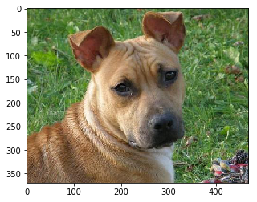

```
Dog Breed: ages/train/008.American_staffordshire_terrier
```

```python
my_dog_breed_detector(train_files[4])
```

## Step 8: Test Your Algorithm

In this section, you will take your new algorithm for a spin! What kind of dog does the algorithm think that **you** look like? If you have a dog, does it predict your dog's breed accurately? If you have a cat, does it mistakenly think that your cat is a dog?

### (IMPLEMENTATION) Test Your Algorithm on Sample Images!

Test your algorithm at least six images on your computer. Feel free to use any images you like. Use at least two human and two dog images.

**Question 6:** Is the output better than you expected :) ? Or worse :( ? Provide at least three possible points of improvement for your algorithm.

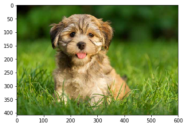

```
Dog Breed: ages/train/107.Norfolk_terrier
```

```python
my_dog_breed_detector('cute-puppy-body-image.jpg')
```

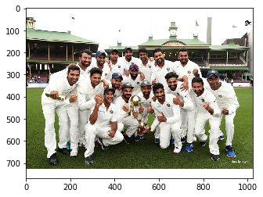

```
That's a human! but looks like (:p)  ages/train/037.Brittany
```

```python
my_dog_breed_detector('india-cricket-team-20a.jpg')
```

[figure not shown]

```
NO detection!
```

```python
my_dog_breed_detector('56355704.png')
```

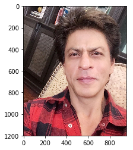

```
That's a human! but looks like (:p)  ages/train/127.Silky_terrier
```

```python
my_dog_breed_detector('2.jpg')
```

[figure not shown]

```
That's a human! but looks like (:p)  ages/train/060.Dogue_de_bordeaux
```

```python
my_dog_breed_detector('bk-3.jpeg')
```

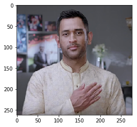

```
That's a human! but looks like (:p)  ages/train/127.Silky_terrier
```

```python
my_dog_breed_detector('dhoni-8.jpg')
```